# Project 3

Moran Guo

*This project, as the rest of the course, is adapted from the version [Stephanie C. Hicks](https://www.stephaniehicks.com/) designed and maintained in 2021 and 2022. Check the recent changes to this file through the [GitHub history](https://github.com/lcolladotor/jhustatcomputing/commits/main/raymond/JHSPH_Stat_Computing/index.qmd).*

# Background

**Due date: October 20th at 11:59pm**

The goal of this assignment is to practice wrangling special data types (including dates, character strings, and factors) and visualizing results while practicing our tidyverse skills.

### To submit your project

Please write up your project using R Markdown and processed with `knitr`. Compile your document as an **HTML file** and submit your HTML file to the dropbox on Courseplus. Please **show all your code** (i.e. make sure to set `echo = TRUE`) for each of the answers to each part.

# Load data

The datasets for this part of the assignment comes from [TidyTuesday](https://www.tidytuesday.com).

Data dictionary available here:

- https://github.com/rfordatascience/tidytuesday/tree/master/data/2020/2020-09-29

[figure not shown]

Beyoncé (left) and Taylor Swift (right)

Specifically, we will explore album sales and lyrics from two artists (Beyoncé and Taylor Swift), The data are available from TidyTuesday from September 2020, which I have provided for you below:

```r
b_lyrics <- readr::read_csv("https://raw.githubusercontent.com/rfordatascience/tidytuesday/master/data/2020/2020-09-29/beyonce_lyrics.csv")
ts_lyrics <- readr::read_csv("https://raw.githubusercontent.com/rfordatascience/tidytuesday/master/data/2020/2020-09-29/taylor_swift_lyrics.csv")
sales <- readr::read_csv("https://raw.githubusercontent.com/rfordatascience/tidytuesday/master/data/2020/2020-09-29/sales.csv")
```

However, to avoid re-downloading data, we will check to see if those files already exist using an `if()` statement:

```r
library("here")
rds_files <- c("b_lyrics.RDS", "ts_lyrics.RDS", "sales.RDS")
## Check whether we have all 3 files
if (any(!file.exists(here("data", rds_files)))) {
    ## If we don't, then download the data
    b_lyrics <- readr::read_csv("https://raw.githubusercontent.com/rfordatascience/tidytuesday/master/data/2020/2020-09-29/beyonce_lyrics.csv")
    ts_lyrics <- readr::read_csv("https://raw.githubusercontent.com/rfordatascience/tidytuesday/master/data/2020/2020-09-29/taylor_swift_lyrics.csv")
    sales <- readr::read_csv("https://raw.githubusercontent.com/rfordatascience/tidytuesday/master/data/2020/2020-09-29/sales.csv")

    ## Then save the data objects to RDS files
    saveRDS(b_lyrics, file = here("data", "b_lyrics.RDS"))
    saveRDS(ts_lyrics, file = here("data", "ts_lyrics.RDS"))
    saveRDS(sales, file = here("data", "sales.RDS"))
}
```

The above code will only run if it cannot find the path to the `b_lyrics.RDS` on your computer. Then, we can just read in these files every time we knit the R Markdown, instead of re-downloading them every time.

Let’s load the datasets

```r
b_lyrics <- readRDS(here("data", "b_lyrics.RDS"))
ts_lyrics <- readRDS(here("data", "ts_lyrics.RDS"))
sales <- readRDS(here("data", "sales.RDS"))
```

# Part 1: Explore album sales

In this section, the goal is to explore the sales of studio albums from Beyoncé and Taylor Swift.

**Notes**

- In each of the subsections below that ask you to create a plot, you must create a title, subtitle, x-axis label, and y-axis label with units where applicable. For example, if your axis says “sales” as an axis label, change it to “sales (in millions)”.

## Part 1A

In this section, we will do some data wrangling.

1. Use `lubridate` to create a column called `released` that is a `Date` class. However, to be able to do this, you first need to use `stringr` to search for pattern that matches things like this “(US)[51]” in a string like this “September 1, 2006 (US)[51]” and removes them. (**Note**: to get full credit, you must create the regular expression).
2. Use `forcats` to create a factor called `country` (**Note**: you may need to collapse some factor levels).
3. Transform the `sales` into a unit that is album sales in millions of dollars.
4. Keep only album sales from the UK, the US or the World.
5. Auto print your final wrangled tibble data frame.

```r
# Load required packages
library(dplyr)
library(stringr)
library(lubridate)
```

```r
library(forcats)
library(here)
library(ggplot2)

str_remove <- "\\s*\\(.*?\\)\\[\\d+\\]"

sales <- sales %>%
  mutate(
    release_cleaned = str_remove_all(released, str_remove),
    released = mdy(release_cleaned)
  )

sales <- sales %>%
  mutate(
    country = fct_recode(country, World = "WW", World = "World")
  )

sales <- sales %>%
  mutate(
    sales_millions = sales / 1e6
  )

filtered_sales <- sales %>%
  filter(country %in% c("UK", "US", "World"))

print(filtered_sales)
```

```
## # A tibble: 36 × 10
##    artist       title        country   sales released   re_release label formats
##    <chr>        <chr>        <fct>     <dbl> <date>     <chr>      <chr> <chr>
##  1 Taylor Swift Taylor Swift US       5.72e6 2006-10-24 March 18,… Big … CD, CD…
##  2 Taylor Swift Fearless     World    1.20e7 2008-11-11 October 2… Big … CD, CD…
##  3 Taylor Swift Fearless     US       7.18e6 2008-11-11 October 2… Big … CD, CD…
##  4 Taylor Swift Fearless     UK       6.09e5 2008-11-11 October 2… Big … CD, CD…
##  5 Taylor Swift Speak Now    World    5   e6 2010-10-25 <NA>       Big … CD, CD…
##  6 Taylor Swift Speak Now    US       4.69e6 2010-10-25 <NA>       Big … CD, CD…
##  7 Taylor Swift Speak Now    UK       1.69e5 2010-10-25 <NA>       Big … CD, CD…
##  8 Taylor Swift Red          World    6   e6 2012-10-22 <NA>       Big … CD, CD…
##  9 Taylor Swift Red          US       4.47e6 2012-10-22 <NA>       Big … CD, CD…
## 10 Taylor Swift Red          UK       6.93e5 2012-10-22 <NA>       Big … CD, CD…
## # ℹ 26 more rows
## # ℹ 2 more variables: release_cleaned <chr>, sales_millions <dbl>
```

## Part 1B

In this section, we will do some more data wrangling followed by summarization using wrangled data from Part 1A.

1. Keep only album sales from the US.
2. Create a new column called `years_since_release` corresponding to the number of years since the release of each album from Beyoncé and Taylor Swift. This should be a whole number and you should round down to “14” if you get a non-whole number like “14.12” years. (**Hint**: you may find the `interval()` function from `lubridate` helpful here, but this not the only way to do this.)
3. Calculate the most recent, oldest, and the median years since albums were released for both Beyoncé and Taylor Swift.

```r
us_sales <- filtered_sales %>%
  filter(country == "US")

us_sales <- us_sales %>%
  mutate(
    years_since_release = as.integer(floor(time_length(interval(released, Sys.Date()), "years")))
  )

summary_stats <- us_sales %>%
  group_by(artist) %>%
  summarise(
    most_recent = min(years_since_release),
    oldest = max(years_since_release),
    median_yrs = median(years_since_release)
  )

# Print the summary statistics
print(summary_stats)
```

```
## # A tibble: 2 × 4
##   artist       most_recent oldest median_yrs
##   <chr>              <int>  <int>      <dbl>
## 1 Beyoncé                8     21         14
## 2 Taylor Swift           5     17         11
```

## Part 1C

Using the wrangled data from Part 1A:

1. Calculate the total album sales for each artist and for each `country` (only sales from the UK, US, and World).
   1. Note: assume that the World sales do not include the UK and US ones.
2. Using the total album sales, create a [percent stacked barchart](https://r-graph-gallery.com/48-grouped-barplot-with-ggplot2) using `ggplot2` of the percentage of sales of studio albums (in millions) along the y-axis for the two artists along the x-axis colored by the `country`.

```r
library(ggplot2)

total_sales <- filtered_sales %>%
  group_by(artist, country) %>%
  summarise(total_sales_millions = sum(sales_millions, na.rm = TRUE)) %>%
  ungroup()
print(total_sales)
```

```
## # A tibble: 6 × 3
##   artist       country total_sales_millions
##   <chr>        <fct>                  <dbl>
## 1 Beyoncé      UK                      5.24
## 2 Beyoncé      US                     17.7
## 3 Beyoncé      World                  34.5
## 4 Taylor Swift UK                      3.32
## 5 Taylor Swift US                     31.7
## 6 Taylor Swift World                  40.8
```

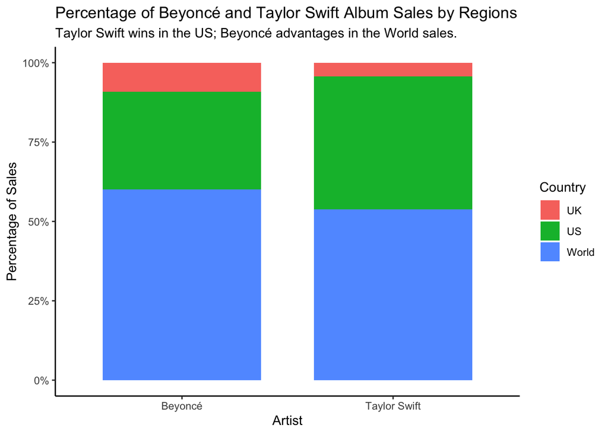

```r
total_sales <- total_sales %>%
  group_by(artist) %>%
  mutate(percentages = (total_sales_millions / sum(total_sales_millions)) * 100) %>%
  ungroup()

ggplot(total_sales, aes(x = artist, y = percentages, fill = country)) +
  geom_bar(stat = "identity", position = "fill", width = 0.75) +
  labs(
    title = "Percentage of Beyoncé and Taylor Swift Album Sales by Regions",
    subtitle = "Taylor Swift wins in the US; Beyoncé advantages in the World sales.",
    x = "Artist",
    y = "Percentage of Sales",
    fill = "Country"
  ) +
  scale_y_continuous(labels = scales::percent_format()) +
  theme_classic()
```

## Part 1D

Using the wrangled data from Part 1A, use `ggplot2` to create a bar plot for the sales of studio albums (in millions) along the x-axis for each of the album titles along the y-axis.

**Note**:

- You only need to consider the global World sales (you can ignore US and UK sales for this part). Hint: how would you abbreviate *WorldWide*?
- The title of the album must be clearly readable along the y-axis.
- Each bar should be colored by which artist made that album.
- The bars should be ordered from albums with the most sales (top) to the least sales (bottom) (**Note**: you must use functions from `forcats` for this step).

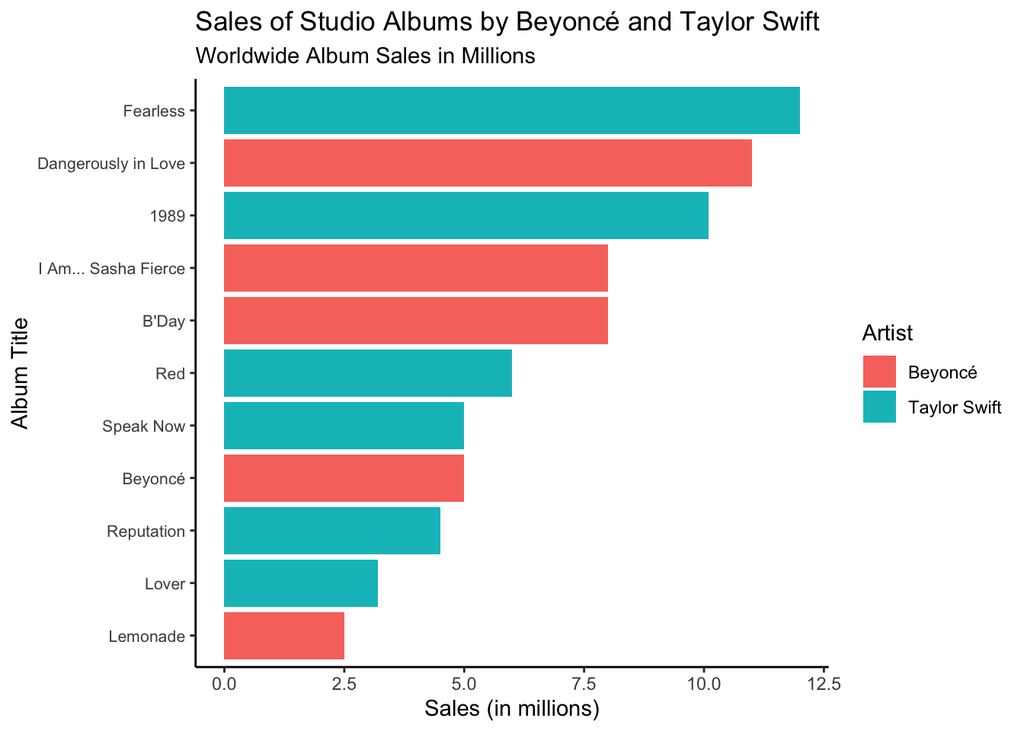

```r
world_sales <- filtered_sales %>%
  filter(country == "World")

# Create the bar plot using ggplot2
ggplot(world_sales, aes(x = fct_reorder(title, as.numeric(sales_millions), .desc = FALSE, .fun = sum), y = sales_millions, fill = artist)) +
  geom_bar(stat = "identity") +
  coord_flip() +
  labs(
    title = "Sales of Studio Albums by Beyoncé and Taylor Swift",
    subtitle = "Worldwide Album Sales in Millions",
    x = "Album Title",
    y = "Sales (in millions)",
    fill = "Artist"
  ) +
  theme_classic() +
  theme(axis.text.y = element_text(size = 8))
```

## Part 1E

Using the wrangled data from Part 1A, use `ggplot2` to create a scatter plot of sales of studio albums (in millions) along the y-axis by the released date for each album along the x-axis.

**Note**:

- The points should be colored by the artist.
- There should be three scatter plots (one for UK, US and world sales) faceted by rows.

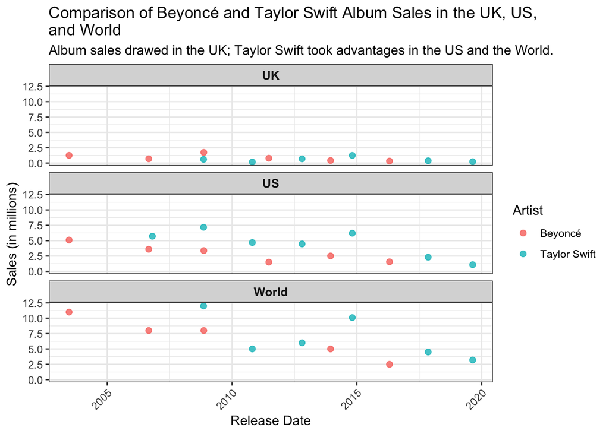

```r
ggplot(filtered_sales, aes(x = released, y = sales_millions, color = artist)) +
  geom_point(size = 2, alpha = 0.8) +
  facet_wrap(~ country, ncol = 1) +
  labs(
    title = "Comparison of Beyoncé and Taylor Swift Album Sales in the UK, US, \nand World",
    subtitle = "Album sales drawed in the UK; Taylor Swift took advantages in the US and the World.",
    x = "Release Date",
    y = "Sales (in millions)",
    color = "Artist"
  ) +
  theme_bw() +
  theme(
    strip.text = element_text(size = 10, face = "bold"),
    axis.text.x = element_text(angle = 45, hjust = 1)
  )
```

# Part 2: Exploring sentiment of lyrics

In Part 2, we will explore the lyrics in the `b_lyrics` and `ts_lyrics` datasets.

## Part 2A

Using `ts_lyrics`, create a new column called `line` with one line containing the character string for each line of Taylor Swift’s songs.

- How many lines in Taylor Swift’s lyrics contain the word “hello”? For full credit, show all the rows in `ts_lyrics` that have “hello” in the `line` column and report how many rows there are in total.
- How many lines in Taylor Swift’s lyrics contain the word “goodbye”? For full credit, show all the rows in `ts_lyrics` that have “goodbye” in the `line` column and report how many rows there are in total.

```r
# Load required packages
library(dplyr)
library(stringr)
library(tidyr)


ts_lyrics <- ts_lyrics %>%
  mutate(line = str_split(Lyrics, pattern = "\\n")) %>%
  unnest(line)

hello_lines <- ts_lyrics %>%
  filter(str_detect(line, regex("\\bhello\\b", ignore_case = TRUE)))

print(hello_lines)
```

```
## # A tibble: 6 × 5
##   Artist       Album    Title                  Lyrics                      line
##   <chr>        <chr>    <chr>                  <chr>                       <chr>
## 1 Taylor Swift Fearless Love Story             "We were both young when I… "And…
## 2 Taylor Swift Red      I Almost Do            "I bet\nThis time of night… "Tha…
## 3 Taylor Swift Red      Everything Has Changed "All I knew\nThis morning … "'Ca…
## 4 Taylor Swift Red      Everything Has Changed "All I knew\nThis morning … "'Ca…
## 5 Taylor Swift Red      Everything Has Changed "All I knew\nThis morning … "All…
## 6 Taylor Swift Red      Everything Has Changed "All I knew\nThis morning … "All…
```

```r
num_hello_lines <- nrow(hello_lines)
cat("Number of lines containing the word 'hello':", num_hello_lines, "\n")
```

```
## Number of lines containing the word 'hello': 6
```

```r
goodbye_lines <- ts_lyrics %>%
  filter(str_detect(line, regex("\\bgoodbye\\b", ignore_case = TRUE)))

print(goodbye_lines)
```

```
## # A tibble: 12 × 5
##    Artist       Album        Title                      Lyrics             line
##    <chr>        <chr>        <chr>                      <chr>              <chr>
##  1 Taylor Swift Taylor Swift Tied Together With A Smile "Seems the only o… "Goo…
##  2 Taylor Swift Speak Now    Mine                       "Oh, oh, oh\nOh, … "Bra…
##  3 Taylor Swift Speak Now    Back to December           "I'm so glad you … "You…
##  4 Taylor Swift Speak Now    Long Live                  "I said remember … "And…
##  5 Taylor Swift Red          I Almost Do                "I bet\nThis time… "And…
##  6 Taylor Swift Red          Come Back Be Here          "You said it in a… "Stu…
##  7 Taylor Swift 1989         All You Had to Do Was Stay "People like you … "But…
##  8 Taylor Swift reputation   Getaway Car                "He was the best … "Sai…
##  9 Taylor Swift reputation   Getaway Car                "He was the best … "Sai…
## 10 Taylor Swift Lover        Death By A Thousand Cuts   "My, my, my, my\n… "Say…
## 11 Taylor Swift Lover        Death By A Thousand Cuts   "My, my, my, my\n… "'Ca…
## 12 Taylor Swift Lover        Daylight                   "My love was as c… "I'l…
```

```r
num_goodbye_lines <- nrow(goodbye_lines)
cat("Number of lines containing the word 'goodbye':", num_goodbye_lines, "\n")
```

```
## Number of lines containing the word 'goodbye': 12
```

## Part 2B

Repeat the same analysis for `b_lyrics` as described in Part 2A.

```r
# Load required packages
library(dplyr)
library(stringr)
library(tidyr)

hello_lines_b <- b_lyrics %>%
  filter(str_detect(line, regex("\\bhello\\b", ignore_case = TRUE)))


#print(hello_lines_b)


num_hello_lines_b <- nrow(hello_lines_b)
cat("Number of lines containing the word 'hello' in Beyonce's lyrics:", num_hello_lines_b, "\n")
```

```
## Number of lines containing the word 'hello' in Beyonce's lyrics: 91
```

```r
goodbye_lines_b <- b_lyrics %>%
  filter(str_detect(line, regex("\\bgoodbye\\b", ignore_case = TRUE)))


#print(goodbye_lines_b)


num_goodbye_lines_b <- nrow(goodbye_lines_b)
cat("Number of lines containing the word 'goodbye' in Beyonce's lyrics:", num_goodbye_lines_b, "\n")
```

```
## Number of lines containing the word 'goodbye' in Beyonce's lyrics: 12
```

## Part 2C

Using the `b_lyrics` dataset,

1. Tokenize each lyrical line by words.
2. Remove the “stopwords”.
3. Calculate the total number for each word in the lyrics.
4. Using the “bing” sentiment lexicon, add a column to the summarized data frame adding the “bing” sentiment lexicon.
5. Sort the rows from most frequent to least frequent words.
6. Only keep the top 25 most frequent words.
7. Auto print the wrangled tibble data frame.
8. Use `ggplot2` to create a bar plot with the top words on the y-axis and the frequency of each word on the x-axis. Color each bar by the sentiment of each word from the “bing” sentiment lexicon. Bars should be ordered from most frequent on the top to least frequent on the bottom of the plot.
9. Create a word cloud of the top 25 most frequent words.

```r
# Load required packages
library(tidytext)
library(wordcloud)
bing_lex <- get_sentiments("bing")

b_tokens <- b_lyrics %>%
  unnest_tokens(word, line)

data("stop_words")
b_tokens_cleaned <- b_tokens %>%
  anti_join(stop_words, by = "word")


word_counts <- b_tokens_cleaned %>%
  count(word, sort = TRUE)

word_sentiments <- word_counts %>%
  inner_join(bing_lex, by = "word")

top_words <- word_sentiments %>%
  top_n(25, n)

print(top_words)
```

```
## # A tibble: 25 × 3
##    word          n sentiment
##    <chr>     <int> <chr>
##  1 love       1362 positive
##  2 crazy       308 negative
##  3 top         241 positive
##  4 bad         132 negative
##  5 beautiful   131 positive
##  6 whoa        121 positive
##  7 damn        106 negative
##  8 hurt         90 negative
##  9 hard         87 negative
## 10 ready        85 positive
## # ℹ 15 more rows
```

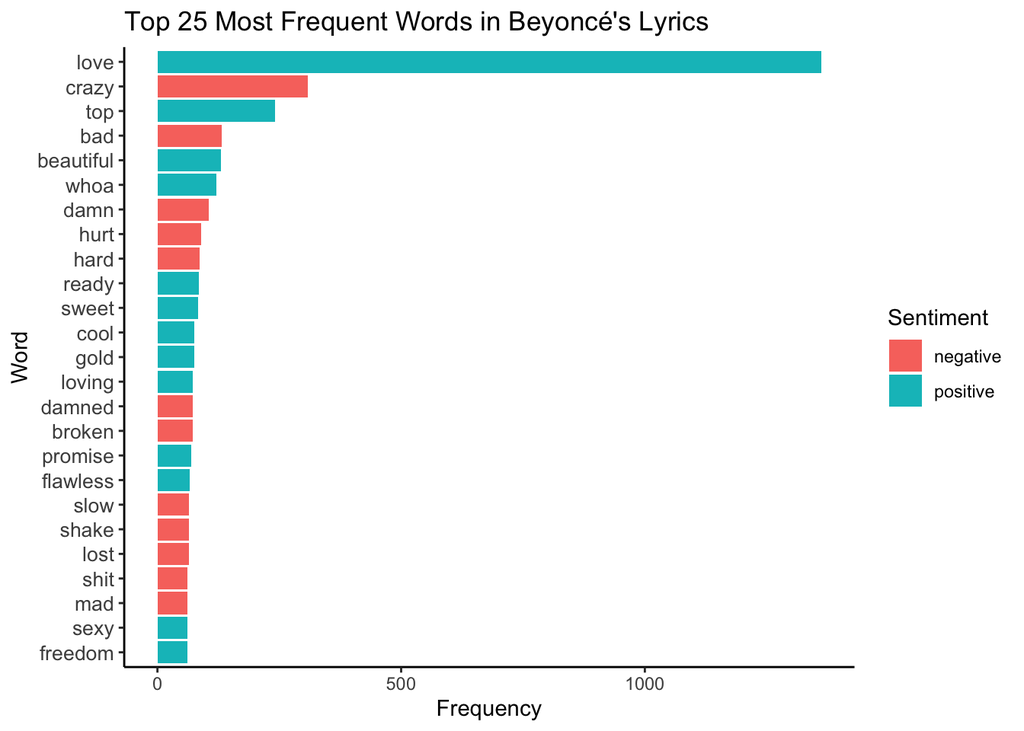

```r
ggplot(top_words, aes(x = reorder(word, n), y = n, fill = sentiment)) +
  geom_bar(stat = "identity") +
  coord_flip() +
  labs(
    title = "Top 25 Most Frequent Words in Beyoncé's Lyrics",
    x = "Word",
    y = "Frequency",
    fill = "Sentiment"
  ) +
  theme_classic() +
  theme(axis.text.y = element_text(size = 10))
```

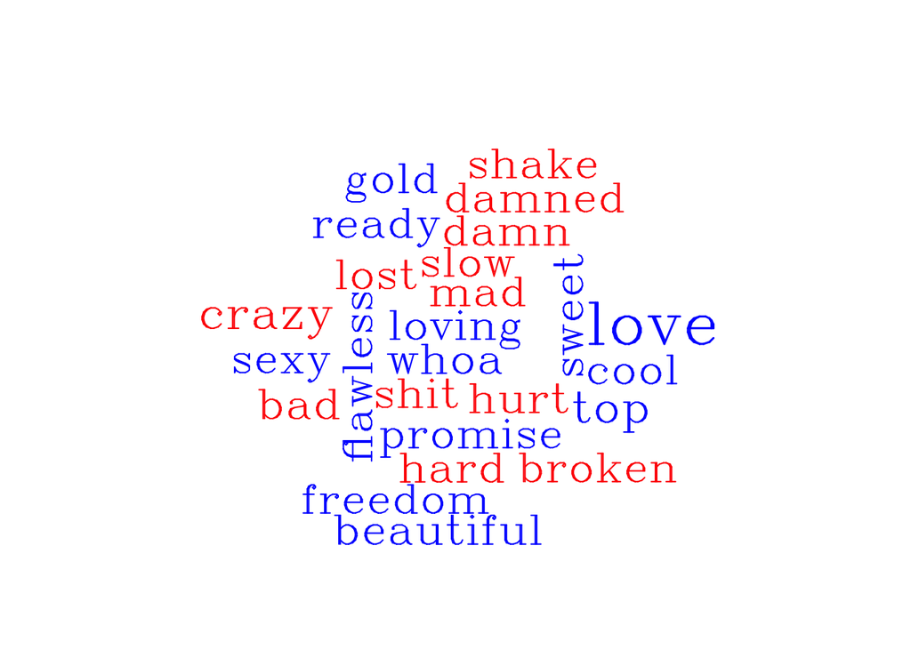

```r
wordcloud(words = top_words$word,
          freq = top_words$n,
          colors = ifelse(top_words$sentiment == "positive", "blue", "red"),
          ordered.colors = TRUE,
          scale = c(3, 2),
          vfont=c("serif","plain"))
```

## Part 2D

Repeat the same analysis as above in Part 2C, but for `ts_lyrics`.

```r
# Load required packages
library(dplyr)
library(tidytext)
library(ggplot2)
library(wordcloud)
library(tidyr)


ts_tokens <- ts_lyrics %>%
  unnest_tokens(word, line)

data("stop_words")
ts_tokens_cleaned <- ts_tokens %>%
  anti_join(stop_words, by = "word")

ts_word_counts <- ts_tokens_cleaned %>%
  count(word, sort = TRUE)

ts_word_sentiments <- ts_word_counts %>%
  inner_join(bing_lex, by = "word")

ts_top_words <- ts_word_sentiments %>%
  top_n(25, n)

print(ts_top_words)
```

```
## # A tibble: 25 × 3
##    word          n sentiment
##    <chr>     <int> <chr>
##  1 love        248 positive
##  2 bad          80 negative
##  3 shake        73 negative
##  4 break        59 negative
##  5 mad          48 negative
##  6 beautiful    46 positive
##  7 smile        45 positive
##  8 hate         44 negative
##  9 fall         43 negative
## 10 whoa         36 positive
## # ℹ 15 more rows
```

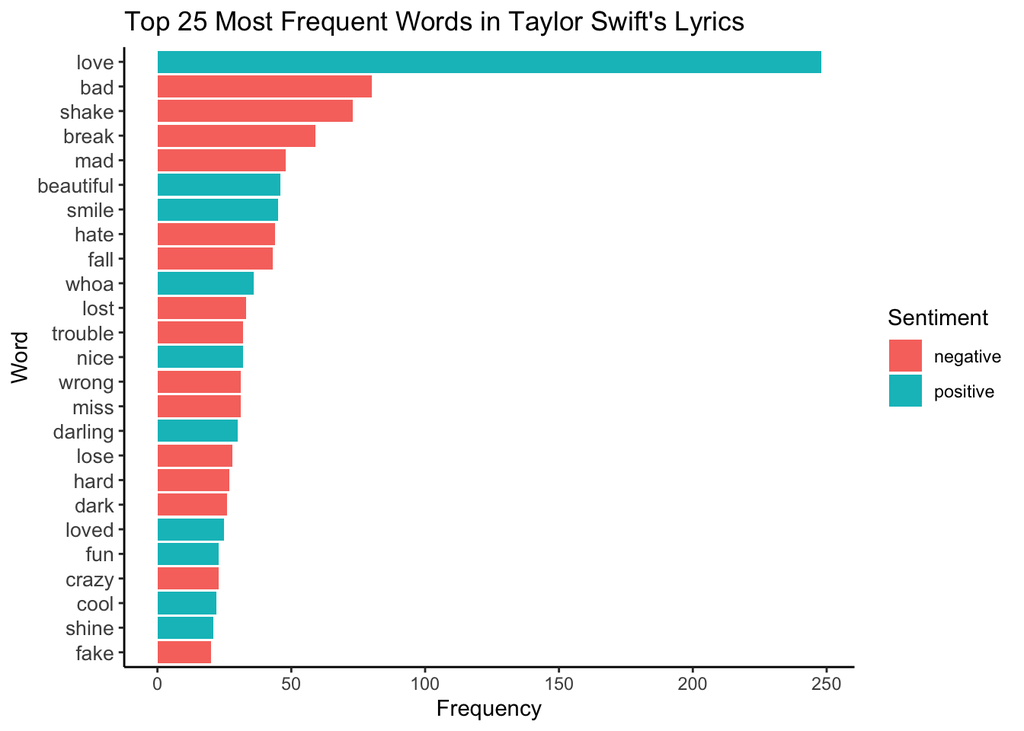

```r
ggplot(ts_top_words, aes(x = reorder(word, n), y = n, fill = sentiment)) +
  geom_bar(stat = "identity") +
  coord_flip() +
  labs(
    title = "Top 25 Most Frequent Words in Taylor Swift's Lyrics",
    x = "Word",
    y = "Frequency",
    fill = "Sentiment"
  ) +
  theme_classic() +
  theme(axis.text.y = element_text(size = 10))
```

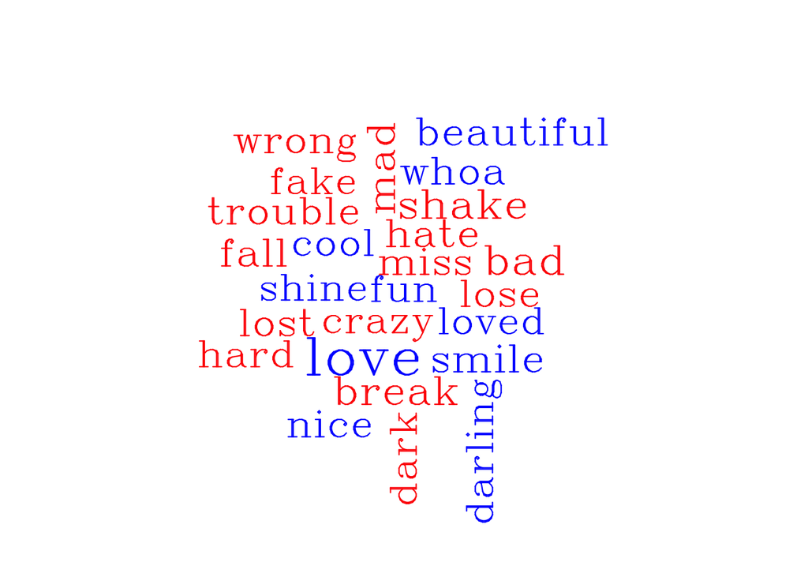

```r
wordcloud(words = ts_top_words$word,
          freq = ts_top_words$n,
          scale = c(3, 2),
          colors = ifelse(ts_top_words$sentiment == "positive", "blue", "red"),
          ordered.colors = TRUE,
          vfont=c("serif","plain"))
```

## Part 2E

Using the `ts_lyrics` dataset,

1. Tokenize each lyrical line by words.
2. Remove the “stopwords”.
3. Calculate the total number for each word in the lyrics **for each Album**.
4. Using the “afinn” sentiment lexicon, add a column to the summarized data frame adding the “afinn” sentiment lexicon.
5. Calculate the average sentiment score **for each Album**.
6. Auto print the wrangled tibble data frame.
7. Join the wrangled data frame from Part 1A (album sales in millions) filtered down to US sales with the wrangled data frame from #6 above (average sentiment score for each album).
8. Using `ggplot2`, create a scatter plot of the average sentiment score for each album (y-axis) and the album release data along the x-axis. Make the size of each point the album sales in millions.
9. Add a horizontal line at y-intercept=0.
10. Write 2-3 sentences interpreting the plot answering the question “How has the sentiment of Taylor Swift’s albums have changed over time?”. Add a title, subtitle, and useful axis labels.

```r
#install.packages('textdata')

word_counts_album <- ts_tokens_cleaned %>%
  count(Album, word, sort = TRUE)


afinn_lex <- get_sentiments("afinn")
word_sentiments_album <- word_counts_album %>%
  inner_join(afinn_lex, by = "word")


average_sentiment_album <- word_sentiments_album %>%
  group_by(Album) %>%
  summarise(average_sentiment = sum(value * n)/sum(n))

average_sentiment_album <- average_sentiment_album %>%
  mutate(Album = ifelse(Album == "reputation", "Reputation", Album))

print(average_sentiment_album)
```

```
## # A tibble: 8 × 2
##   Album        average_sentiment
##   <chr>                    <dbl>
## 1 1989                   -0.215
## 2 Fearless                0.452
## 3 Lover                   0.0960
## 4 Red                     0.256
## 5 Speak Now               0.0219
## 6 Taylor Swift            0.646
## 7 folklore               -0.396
## 8 Reputation              0.0501
```

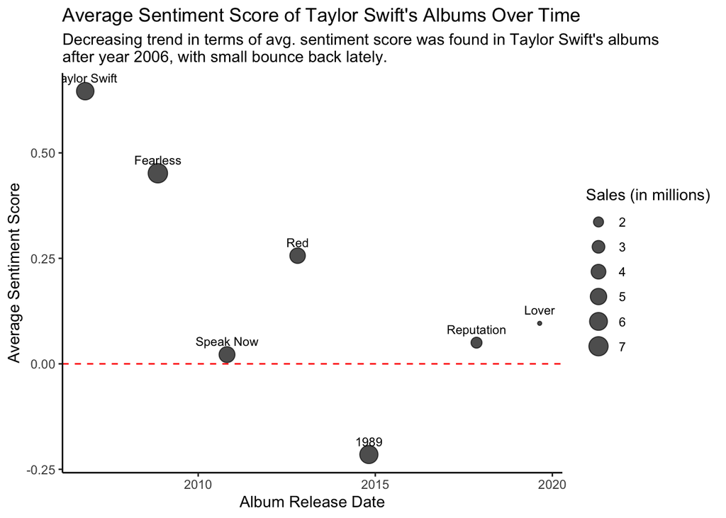

```r
us_sales <- filtered_sales %>% filter(country == "US")


combined_data <- us_sales %>%
  inner_join(average_sentiment_album, by = c("title" = "Album"))

ggplot(combined_data, aes(x = released, y = average_sentiment, size = sales_millions)) +
  geom_point(alpha = 0.7) +
  geom_text(aes(label = title), vjust = -1, size = 3) +
  geom_hline(yintercept = 0, linetype = "dashed", color = "red") +
  labs(
    title = "Average Sentiment Score of Taylor Swift's Albums Over Time",
    subtitle = "Decreasing trend in terms of avg. sentiment score was found in Taylor Swift's albums \nafter year 2006, with small bounce back lately.",
    x = "Album Release Date",
    y = "Average Sentiment Score",
    size = "Sales (in millions)"
  ) +
  theme_classic()
```

Interpretation: We could generally observe a decreasing trend in terms of the average sentiment score of Taylor Swift’s albums from year 2006. It seems that after year 2006, the sentiment of Taylor Swifts’ songs became more and more negative. However, we can see that at year 2019, she released an album “Lover” with a slightly positive sentiment score.

# R session information

```r
options(width = 120)
```